# DNAm Smoking Exposure Signature

Lauren Vanderlinden

Report generated: March 11, 2024

# Overview

Made 2 different DNAm smoking signatures based on Reese 2017 (https://pubmed.ncbi.nlm.nih.gov/27323799/) and on McCartney 2018 (https://pubmed.ncbi.nlm.nih.gov/30257690/).

Made these scores on EVERY SAMPLE that has DNAm. Then depending on the analyses, folks can subset and/or dichotomize as needed. Just a reminder in the full datasets we have 687 samples on the 450K and 475 samples on the EPIC. Note: this includes technical replicates. When removing technical replicates, we have a total of **641** on 450K and **475** on EPIC (**1116** samples total). These 1,116 is what is used for the following analyses.

# Correlation

Let’s first compare the McCartney and Reese scores.

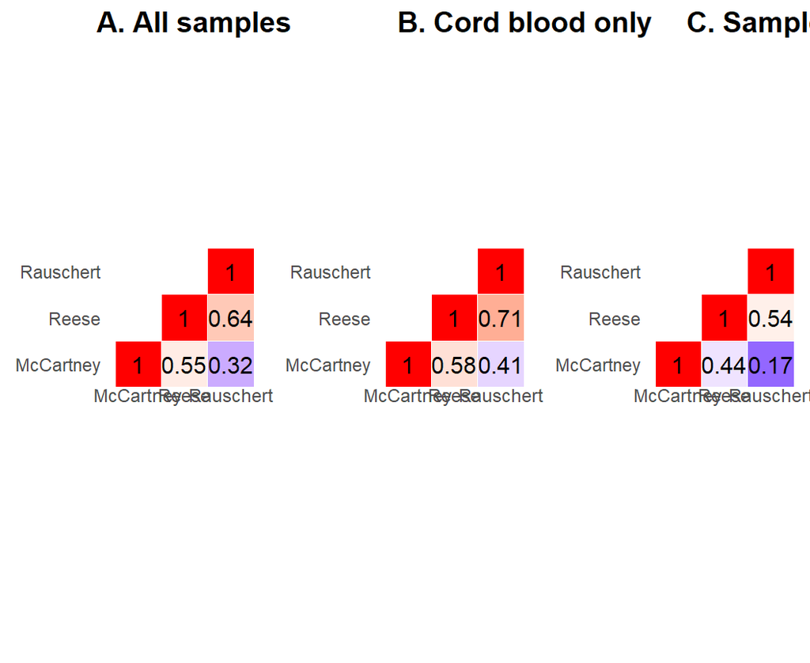

```r
load(file="C:/Users/vanderll/Documents/Norris/smokingExposure_DNAmSignature/data/bothSmokingSignatures.Rdata")
load(file="C:/Users/vanderll/Documents/Norris/smokingExposure_DNAmSignature/data/ML_smokeScore.Rdata")
load(file="C:/Users/vanderll/Documents/Norris/smokingExposure_DNAmSignature/dataRaw/pheno.forMadj.platformAdj.Rdata")

both.smokes2 = merge(both.smokes, ML_smokeScores, by.x="array", by.y="samples")

both.smokes2.wP = merge(both.smokes2, pheno.want, by="array")

#### Make a heatmap of the correlations of the signatures
cormat <- round(cor(both.smokes2[,c(3,4,6)]),2)
cormat.CB <- round(cor(both.smokes2.wP[which(both.smokes2.wP$Visit_Type=="CWB"),c(3,4,6)]),2)

both.smokes.last <- both.smokes2.wP[order(both.smokes2.wP$ID, both.smokes2.wP$clinage, decreasing=TRUE),]
both.smokes.last <- both.smokes.last[!duplicated(both.smokes.last$ID),]

cormat.last <- round(cor(both.smokes.last[,c(3,4,6)]),2)

cormat.10plus <- round(cor(both.smokes2.wP[which(both.smokes2.wP$clinage>10),c(3,4,6)]),2)

#head(cormat)

colnames(cormat) = c("McCartney", "Reese", "Rauschert")
rownames(cormat)= c("McCartney", "Reese", "Rauschert")

colnames(cormat.10plus) = c("McCartney", "Reese", "Rauschert")
rownames(cormat.10plus)= c("McCartney", "Reese", "Rauschert")


colnames(cormat.CB) = c("McCartney", "Reese", "Rauschert")
rownames(cormat.CB)= c("McCartney", "Reese", "Rauschert")

colnames(cormat.last) = c("McCartney", "Reese", "Rauschert")
rownames(cormat.last)= c("McCartney", "Reese", "Rauschert")

library(reshape2)


melted_cormat <- melt(cormat)
# Get upper triangle of the correlation matrix
  get_upper_tri <- function(cormat){
    cormat[lower.tri(cormat)]<- NA
    return(cormat)
  }

upper_tri <- get_upper_tri(cormat)
melted_cormat <- melt(upper_tri, na.rm = TRUE)

upper_tri.CB <- get_upper_tri(cormat.CB)
melted_cormat.CB <- melt(upper_tri.CB, na.rm = TRUE)


upper_tri.last <- get_upper_tri(cormat.last)
melted_cormat.last <- melt(upper_tri.last, na.rm = TRUE)

upper_tri.10plus <- get_upper_tri(cormat.10plus)
melted_cormat.10plus <- melt(upper_tri.10plus, na.rm = TRUE)

# Heatmap
library(ggplot2)

#melted_cormat.all = rbind(melted_cormat, melted_cormat.CB, melted_cormat.last)
ggheatmap <- ggplot(data = melted_cormat, aes(Var2, Var1, fill = value))+
 geom_tile(color = "white")+
 scale_fill_gradient2(low = "blue", high = "red", mid = "white",
   midpoint = 0.5, limit = c(0,1), space = "Lab",
   name="Pearson\nCorrelation") +
  theme_minimal()+
 theme(axis.text.x = element_text(angle = 0, vjust = 5, size = 9, hjust = 0.5))+
 coord_fixed()
ggheatmap.CB <- ggplot(data = melted_cormat.CB, aes(Var2, Var1, fill = value))+
 geom_tile(color = "white")+
 scale_fill_gradient2(low = "blue", high = "red", mid = "white",
   midpoint = 0.5, limit = c(0,1), space = "Lab",
   name="Pearson\nCorrelation") +
  theme_minimal()+
 theme(axis.text.x = element_text(angle = 0, vjust = 5, size = 9, hjust = 0.5))+
 coord_fixed()
ggheatmap.10plus <- ggplot(data = melted_cormat.10plus, aes(Var2, Var1, fill = value))+
 geom_tile(color = "white")+
 scale_fill_gradient2(low = "blue", high = "red", mid = "white",
   midpoint = 0.5, limit = c(0,1), space = "Lab",
   name="Pearson\nCorrelation") +
  theme_minimal()+
 theme(axis.text.x = element_text(angle = 0, vjust = 5, size = 9, hjust = 0.5))+
 coord_fixed()

legend.only <- cowplot::get_legend(ggheatmap+theme_bw()+theme(legend.direction = "horizontal"))
corHeat.10plus <- ggheatmap.10plus +
geom_text(aes(Var2, Var1, label = value), color = "black", size = 4) +
  theme(axis.title.x = element_blank(),
  axis.title.y = element_blank(),
  panel.grid.major = element_blank(),
  panel.border = element_blank(),
  panel.background = element_blank(),
  legend.position="none",
  axis.ticks = element_blank())

corHeat <- ggheatmap +
geom_text(aes(Var2, Var1, label = value), color = "black", size = 4) +
  theme(axis.title.x = element_blank(),
  axis.title.y = element_blank(),
  panel.grid.major = element_blank(),
  panel.border = element_blank(),
  panel.background = element_blank(),
  legend.position="none",
  axis.ticks = element_blank())

corHeat.CB <- ggheatmap.CB +
geom_text(aes(Var2, Var1, label = value), color = "black", size = 4) +
  theme(axis.title.x = element_blank(),
  axis.title.y = element_blank(),
  panel.grid.major = element_blank(),
  panel.border = element_blank(),
  panel.background = element_blank(),
  legend.position="none",
  axis.ticks = element_blank())

library(ggpubr)
ggarrange(corHeat, corHeat.CB, corHeat.10plus, ncol=3, widths =c(1,1,1), heights=c(1),labels=c("A. All samples", "B. Cord blood only", "C. Samples 10+ years", ""))
```

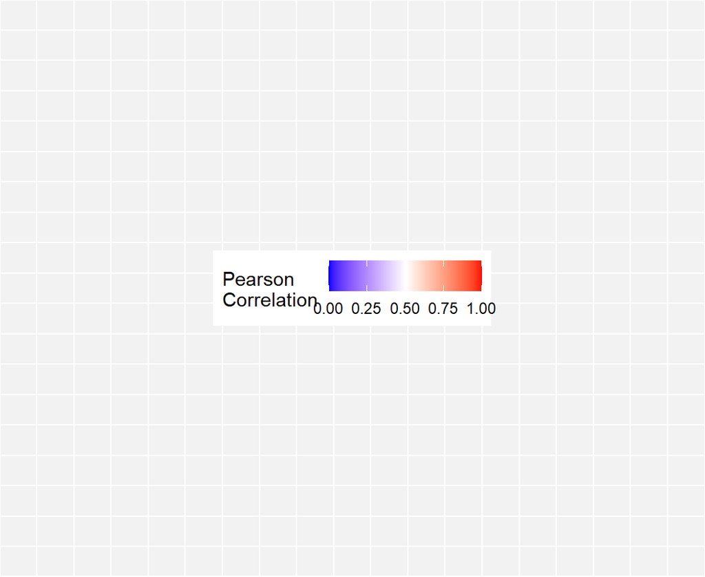

```r
plot(legend.only)
```

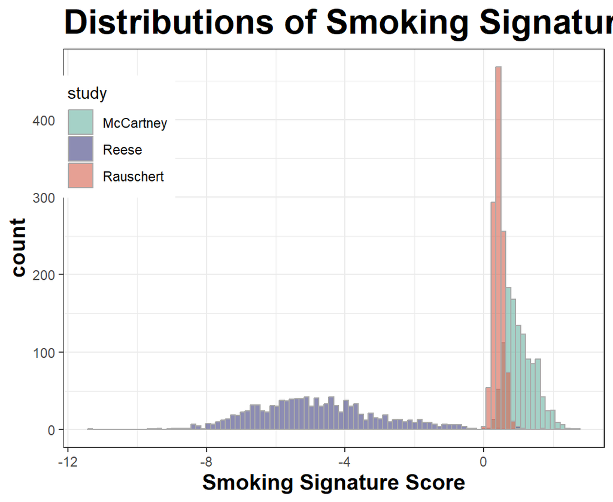

```r
##### What about distribution plots? #####
# get overlap histogram plots #




forHist = data.frame(signature = c(both.smokes2$DNAm.smoke.McCartney, both.smokes2$DNAm.smoke.Reese, both.smokes2$normalized_smokeScore), study = c(rep("McCartney", nrow(both.smokes2)), rep("Reese", nrow(both.smokes2)), rep("Rauschert", nrow(both.smokes2))))
forHist$study = factor(forHist$study, levels=c("McCartney", "Reese", "Rauschert"))

ggplot(forHist, aes(x=signature, fill=study)) +
    geom_histogram(color= "darkgray", alpha=0.6, position = 'identity', bins=100) +
    scale_fill_manual(values=c("#69b3a2", "#404080", "#D6604D")) +
  theme_bw()+
  theme(legend.position = c(0.1,0.78), axis.title=element_text(size=14,face="bold"),
        plot.title = element_text(size=22,face="bold"))+
    xlab("Smoking Signature Score")+
    labs(title="Distributions of Smoking Signatures in DAISY")
```

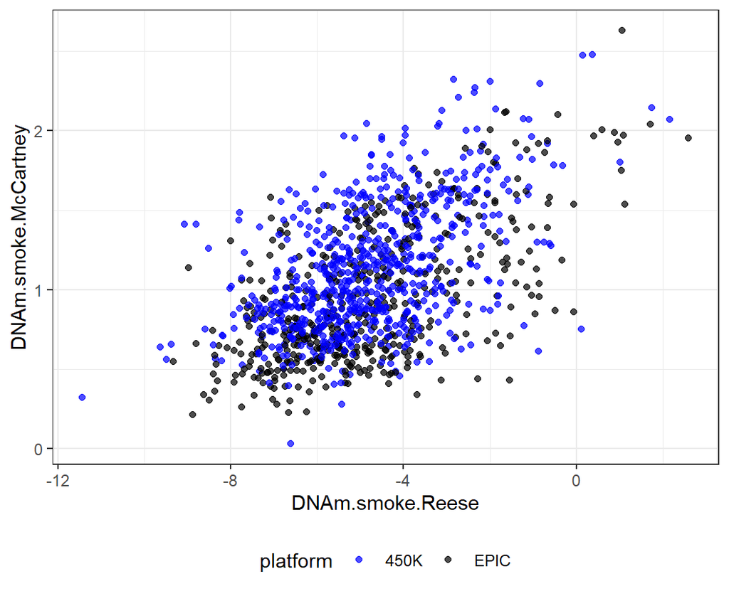

```r
#### scatter plots to show correlation
ggplot(both.smokes, aes(x = DNAm.smoke.Reese, y = DNAm.smoke.McCartney, color = platform)) +
  geom_point(alpha=0.7)+
  scale_color_manual(values=c("blue", "black"))+
  scale_fill_manual(values=c("blue", "black")) +
  #geom_smooth(method = "lm", se = FALSE) +
  theme_bw()+
  theme(legend.position = "bottom")
```

```r
cor.both = cor.test(x=both.smokes$DNAm.smoke.Reese, y = both.smokes$DNAm.smoke.McCartney)
cor.both.spearman = cor.test(x=both.smokes$DNAm.smoke.Reese, y = both.smokes$DNAm.smoke.McCartney, method="spearman")


cor.450 = cor.test(x=both.smokes$DNAm.smoke.Reese[which(both.smokes$platform=="450K")], y = both.smokes$DNAm.smoke.McCartney[which(both.smokes$platform=="450K")])
cor.EPIC = cor.test(x=both.smokes$DNAm.smoke.Reese[which(both.smokes$platform=="EPIC")], y = both.smokes$DNAm.smoke.McCartney[which(both.smokes$platform=="EPIC")])

toPrint = data.frame(data = c("Both Platforms", "450K", "EPIC"), correlation = round(c(cor.both$estimate, cor.450$estimate, cor.EPIC$estimate), 3), pvalue = formatC(c(cor.both$p.value, cor.450$p.value, cor.EPIC$p.value), format="e", digits=2))
colnames(toPrint) = c("Data", "Correlation Coefficient", "p-value")

kable(toPrint, row.names=0, align='l')  %>%
 kable_styling(bootstrap_options = c("striped", "hover"), full_width = F)
```

| Data | Correlation Coefficient | p-value |
| --- | --- | --- |
| Both Platforms | 0.550 | 1.01e-92 |
| 450K | 0.524 | 1.21e-49 |
| EPIC | 0.606 | 6.82e-49 |

# ICC

Look at the intra-class coefficient. This looks at how strongly the smoking signature score in the same subject resemble each other. I’m using the clinical age as time.

linear mixed model used:

$$DNAm Smoking Signature = Age + Platform + random(Age|ID)$$
The adjusted ICC only relates to the random effects, the unadjusted ICC also takes the fixed effects variances into account, more precisely, the fixed effects variance is added to the denominator of the formula to calculate the ICC. I’m going to report both.

```r
load(file="C:/Users/vanderll/Documents/Norris/smokingExposure_DNAmSignature/dataRaw/pheno.forMadj.platformAdj.Rdata")
smoke.wPheno = merge(both.smokes, pheno.want, by="array")
smoke.wPheno2 = merge(both.smokes2, pheno.want, by="array")

smoke.wPheno.noTR = smoke.wPheno[!duplicated(smoke.wPheno$samplekey),]

McCartney.mixMod <- lme(scale(DNAm.smoke.McCartney) ~ clinage + platform, data = smoke.wPheno.noTR, random = ~ clinage | ID)
Reese.mixMod <- lme(scale(DNAm.smoke.Reese) ~ clinage + platform, data = smoke.wPheno.noTR, random = ~ clinage | ID )
Rauschert.mixMod <- lme(scale(normalized_smokeScore) ~ clinage + platform, data=smoke.wPheno2, random = ~clinage | ID)
#McCartney.mixMod <- lme(DNAm.smoke.McCartney ~ clinage + platform, data = smoke.wPheno.noTR, random = ~ 1 | ID)
#Reese.mixMod <- lme(DNAm.smoke.Reese ~ clinage + platform, data = smoke.wPheno.noTR, random = ~ 1 | ID )

#smoke.wPheno.noTR$CBsample = smoke.wPheno.noTR$Visit_Type=="CWB"
#McCartney.mixMod <- lme(DNAm.smoke.McCartney ~ CBsample + clinage + platform, data = smoke.wPheno.noTR, random = ~ clinage | ID)
#Reese.mixMod <- lme(DNAm.smoke.Reese ~ CBsample + clinage + platform, data = smoke.wPheno.noTR, random = ~ clinage | ID)

set.seed(123)
#mccartney.icc = performance::icc(McCartney.mixMod, ci=TRUE)
mccartney.icc = performance::icc(McCartney.mixMod, ci=NULL)

set.seed(123)
#reese.icc = performance::icc(Reese.mixMod, ci=TRUE, tolerance=1e-2)
reese.icc = performance::icc(Reese.mixMod, ci=NULL, tolerance=1e-2)

#reese.icc = performance::icc(Reese.mixMod, ci=TRUE, tolerance=1e-07)

set.seed(123)
rauschert.icc = performance::icc(Rauschert.mixMod, ci=NULL)
#rauschert.icc = performance::icc(Rauschert.mixMod, ci=TRUE, tolerance=1e-2)

icc.print = data.frame(signature = c("McCartney", "Reese", "Rauschert"), Adjusted.ICC = round(c(mccartney.icc$ICC_adjusted, reese.icc$ICC_adjusted, rauschert.icc$ICC_adjusted),2), Unadjusted.ICC =  round(c(mccartney.icc$ICC_unadjusted, reese.icc$ICC_unadjusted, rauschert.icc$ICC_unadjusted),2))

#performance::check_singularity(Reese.mixMod, tolerance = 2.5)


kable(icc.print, row.names=0, align='l')  %>%
 kable_styling(bootstrap_options = c("striped", "hover"), full_width = F)
```

| signature | Adjusted.ICC | Unadjusted.ICC |
| --- | --- | --- |
| McCartney | 0.39 | 0.20 |
| Reese | 0.75 | 0.64 |
| Rauschert | 0.83 | 0.77 |

Wow! Reese has a much higher ICC. **To-do** get 95% CI intervals around the ICC estimates, but need to do bootstraps and this will take awhile to run.

What is also interesting is that in the mixed models, platform is extremely significant in the McCartney signature score, while Reese is not.

**McCartney Fixed Effects Table from Mixed Model**

```r
summary(McCartney.mixMod)$tTable
```

```
##                   Value  Std.Error  DF   t-value       p-value
## (Intercept)   0.8855461 0.04633747 691  19.11080  1.105614e-65
## clinage      -0.1519010 0.00554116 691 -27.41322 1.548069e-112
## platformEPIC -0.5099872 0.05413153 691  -9.42126  6.550811e-20
```

**Reese Fixed Effects Table from Mixed Model**

```r
summary(Reese.mixMod)$tTable
```

```
##                     Value   Std.Error  DF      t-value      p-value
## (Intercept)   0.389886692 0.060490012 691   6.44547222 2.162402e-10
## clinage      -0.081500969 0.004865073 691 -16.75225938 4.046008e-53
## platformEPIC -0.004865172 0.079127736 691  -0.06148504 9.509907e-01
```

**Rauschert Fixed Effects Table from Mixed Model**

```r
summary(Rauschert.mixMod)$tTable
```

```
##                    Value   Std.Error  DF     t-value      p-value
## (Intercept)   0.31897290 0.059068304 737   5.4000688 8.993894e-08
## clinage      -0.05940478 0.003863847 737 -15.3745174 1.794633e-46
## platformEPIC -0.02907068 0.075762015 737  -0.3837106 7.013037e-01
```

Maybe the reasoning why platform matters a lot in McCartney is it uses more probes?

# Visualization

Going to look at our visit time classifications (CB, EV, PreSV, SV, and preT1D).

**Box Plots**

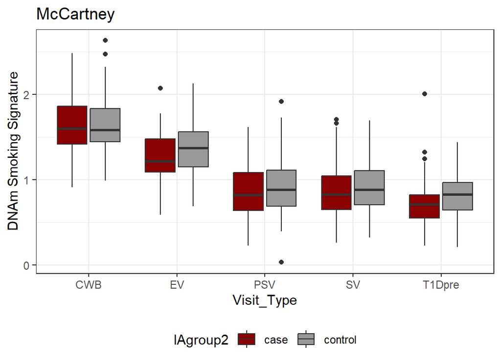

```r
smoke.wPheno.noTR$IAgroup2[which(smoke.wPheno.noTR$IAgroup2=="")]="control"
ggplot(smoke.wPheno.noTR, aes(x=Visit_Type, y=DNAm.smoke.McCartney, fill=IAgroup2)) +
    geom_boxplot() +
   scale_fill_manual(values=c("red4", "#999999"))+
  theme_bw()+
  ylab("DNAm Smoking Signature")+
  ggtitle("McCartney")+
  theme(legend.position = "bottom")
```

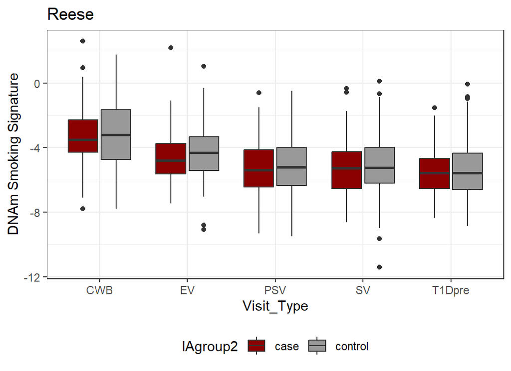

```r
ggplot(smoke.wPheno.noTR, aes(x=Visit_Type, y=DNAm.smoke.Reese, fill=IAgroup2)) +
    geom_boxplot() +
   scale_fill_manual(values=c("red4", "#999999"))+
  theme_bw()+
  ylab("DNAm Smoking Signature")+
  ggtitle("Reese")+
  theme(legend.position = "bottom")
```

**Spaghetti Plots**

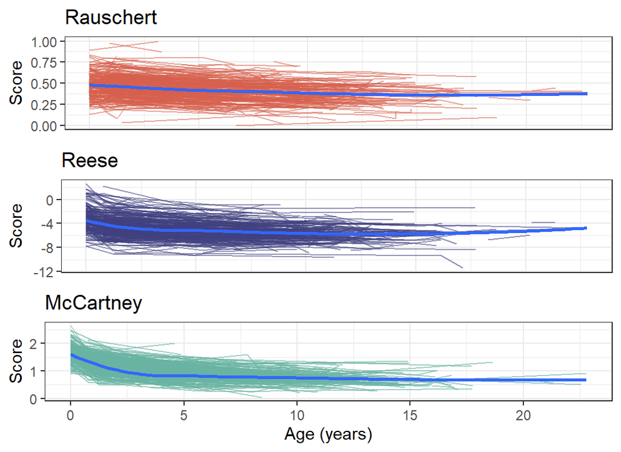

```r
McCartney.s <- ggplot(smoke.wPheno.noTR, aes(x=clinage, y=DNAm.smoke.McCartney, group = ID)) +
    geom_line(color="#69b3a2", alpha=0.6) +
   scale_fill_manual(values=c("#69b3a2"))+
   scale_colour_manual(values=c("#69b3a2"))+
  geom_smooth(aes(group = 1), method="loess", formula=y~x, se=FALSE)+
    theme_bw()+
  ylab("Score")+
  ggtitle("McCartney")+
  xlab("Age (years)")+
  theme(legend.position = "none")

Reese.s <- ggplot(smoke.wPheno.noTR, aes(x=clinage, y=DNAm.smoke.Reese, group = ID)) +
    geom_line(aes(color="#404080", alpha=0.6)) +
   scale_fill_manual(values=c("#404080"))+
   scale_colour_manual(values=c("#404080"))+
  geom_smooth(aes(group = 1), method="loess", formula=y~x, se=FALSE)+
    theme_bw()+
  ylab("Score")+
  ggtitle("Reese")+
  xlab("")+
  theme(legend.position = "none", axis.text.x = element_blank(), axis.ticks.x = element_blank(), axis.title.x = element_blank() )

Rauschert.s <- ggplot(smoke.wPheno2, aes(x=clinage, y=normalized_smokeScore, group = ID)) +
  geom_line(aes(color="#D6604D", alpha=0.6)) +
   scale_fill_manual(values=c("#D6604D"))+
   scale_colour_manual(values=c("#D6604D"))+
  geom_smooth(aes(group = 1), method="loess", formula=y~x, se=FALSE)+
    theme_bw()+
  ylab("Score")+
  ggtitle("Rauschert")+
  xlab("")+
  theme(legend.position = "none", axis.text.x = element_blank(), axis.ticks.x = element_blank(), axis.title.x = element_blank() )

#McCartney.s
#Reese.s
#Rauschert.s
ggarrange(Rauschert.s, Reese.s, McCartney.s, ncol=1, widths=6, heights=c(12, 12, 14))
```

**Bland-Altman Plots**

Here, lets look at the difference from those with cord blood only. We can also expand to the those without cord blood and instead of having the cord blood as the reference, we can plot the mean of samples.

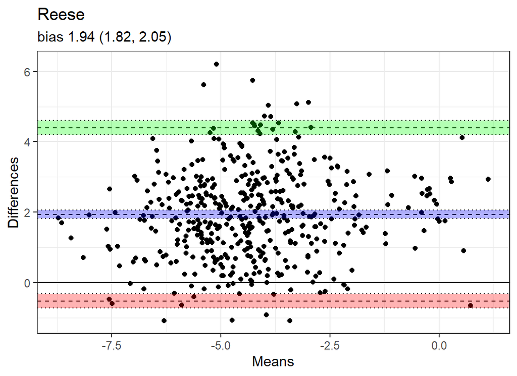

```r
#first we need to get the data in the right format. A dataframe with "method 1", "method 2")

CB = smoke.wPheno2[which(smoke.wPheno2$Visit_Type=="CWB"),]
notCB = smoke.wPheno2[-which(smoke.wPheno2$Visit_Type=="CWB"),]

CB.2 = CB[,c(10, 16, 2, 3, 4, 6)]
notCB.2 = notCB[,c(10, 2,3,4,6,18)]

colnames(CB.2) = c("ID", "sex", "platform.CB", "McCartney_CB", "Reese_CB", "Rauschert_CB")
colnames(notCB.2) = c("ID", "platform.notCB", "McCartney_notCB", "Reese_notCB", "Rauschert_notCB", "age")

forBA = merge(CB.2, notCB.2, by="ID")
BAstats_Reese = blandr.statistics(forBA$Reese_CB, forBA$Reese_notCB)
BAstats_McCartney = blandr.statistics(forBA$McCartney_CB, forBA$McCartney_notCB)


forBA$Reese_diff = forBA$Reese_CB - forBA$Reese_notCB
forBA$McCartney_diff = forBA$McCartney_CB - forBA$McCartney_notCB

Reese_biasInfo = paste0("bias ", round(BAstats_Reese$bias, 2), " (", round(BAstats_Reese$biasLowerCI, 2), ", ", round(BAstats_Reese$biasUpperCI, 2), ")")
McCartney_biasInfo = paste0("bias ", round(BAstats_McCartney$bias, 2), " (", round(BAstats_McCartney$biasLowerCI, 2), ", ", round(BAstats_McCartney$biasUpperCI, 2), ")")


blandr.plot.ggplot(BAstats_Reese) +
  labs(title="Reese", subtitle = Reese_biasInfo)+
  theme_bw()
```

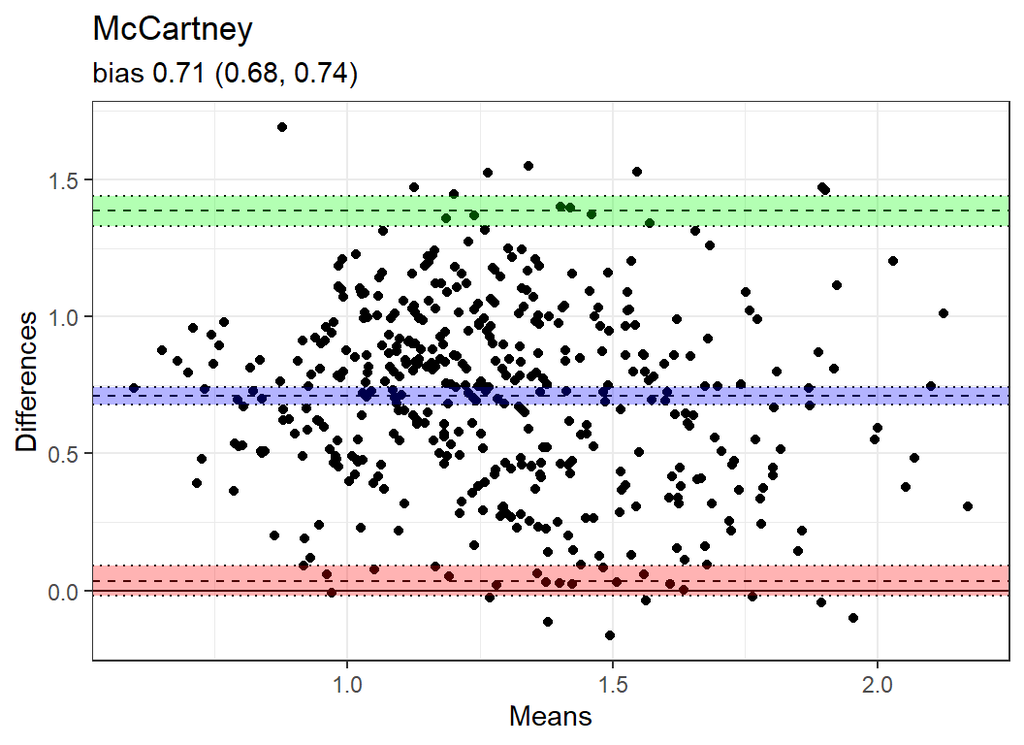

```r
blandr.plot.ggplot(BAstats_McCartney)+
  labs(title="McCartney", subtitle = McCartney_biasInfo)+
  theme_bw()
```

Okay, so these are surprising results. With the ICC you would think the Reese would be more tight. Maybe we need to look at the bland altman on standardized scores (i.e. z-score). The distribution is different between the 2, so lets do the above process again, but this time with the z-scores of each smoking signature. Maybe more comparable.

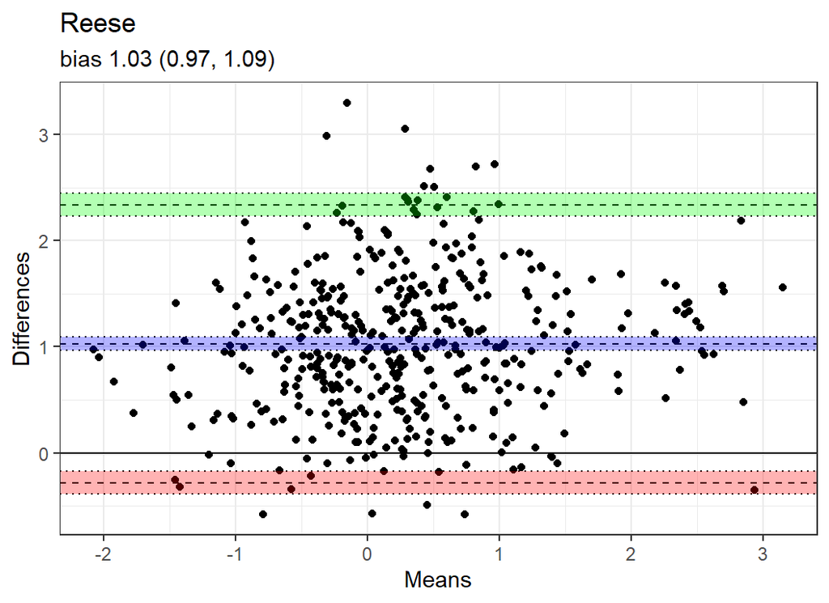

```r
#first we need to get the data in the right format. A dataframe with "method 1", "method 2")
smoke.wPheno2$Reese_zscore = scale(smoke.wPheno2$DNAm.smoke.Reese)
smoke.wPheno2$McCartney_zscore = scale(smoke.wPheno2$DNAm.smoke.McCartney)
smoke.wPheno2$Rauschert_zscore = scale(smoke.wPheno2$normalized_smokeScore)


CB = smoke.wPheno2[which(smoke.wPheno2$Visit_Type=="CWB"),]
notCB = smoke.wPheno2[-which(smoke.wPheno2$Visit_Type=="CWB"),]

CB.2 = CB[,c(10, 16, 2, 26, 25, 27)]
notCB.2 = notCB[,c(10, 2,26,25, 27,18)]

colnames(CB.2) = c("ID", "sex", "platform.CB", "McCartney_CB", "Reese_CB", "Rauschert_CB")
colnames(notCB.2) = c("ID", "platform.notCB", "McCartney_notCB", "Reese_notCB", "Rauschert_notCB", "age")

forBA = merge(CB.2, notCB.2, by="ID")
BAstats_Reese = blandr.statistics(forBA$Reese_CB, forBA$Reese_notCB)
BAstats_McCartney = blandr.statistics(forBA$McCartney_CB, forBA$McCartney_notCB)
BAstats_Rauschert = blandr.statistics(forBA$Rauschert_CB, forBA$Rauschert_notCB)

forBA$Reese_diff = forBA$Reese_CB - forBA$Reese_notCB
forBA$McCartney_diff = forBA$McCartney_CB - forBA$McCartney_notCB
forBA$Rauschert_diff = forBA$Rauschert_CB - forBA$Rauschert_notCB


Reese_biasInfo = paste0("bias ", round(BAstats_Reese$bias, 2), " (", round(BAstats_Reese$biasLowerCI, 2), ", ", round(BAstats_Reese$biasUpperCI, 2), ")")
McCartney_biasInfo = paste0("bias ", round(BAstats_McCartney$bias, 2), " (", round(BAstats_McCartney$biasLowerCI, 2), ", ", round(BAstats_McCartney$biasUpperCI, 2), ")")

Rauschert_biasInfo = paste0("bias ", round(BAstats_Rauschert$bias, 2), " (", round(BAstats_Rauschert$biasLowerCI, 2), ", ", round(BAstats_Rauschert$biasUpperCI, 2), ")")

blandr.plot.ggplot(BAstats_Reese) +
  labs(title="Reese", subtitle = Reese_biasInfo)+
  theme_bw()
```

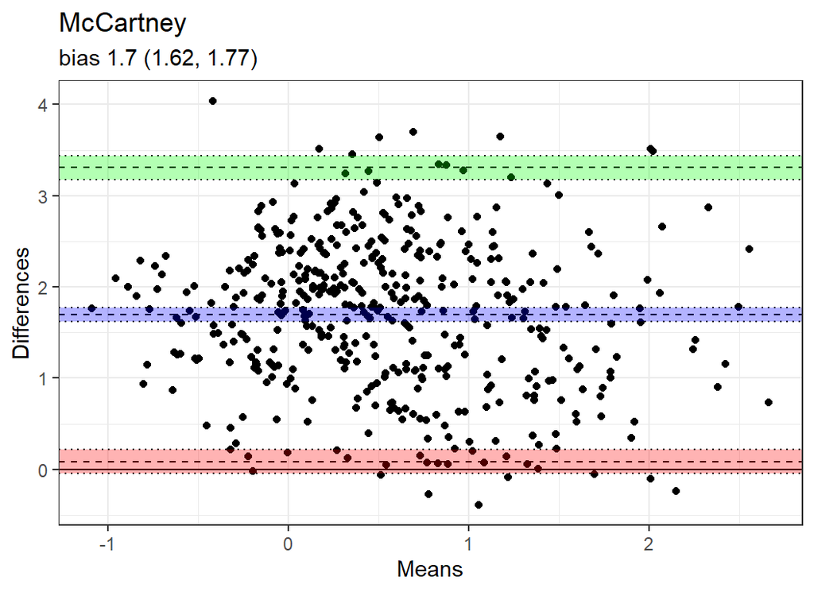

```r
blandr.plot.ggplot(BAstats_McCartney)+
  labs(title="McCartney", subtitle = McCartney_biasInfo)+
  theme_bw()
```

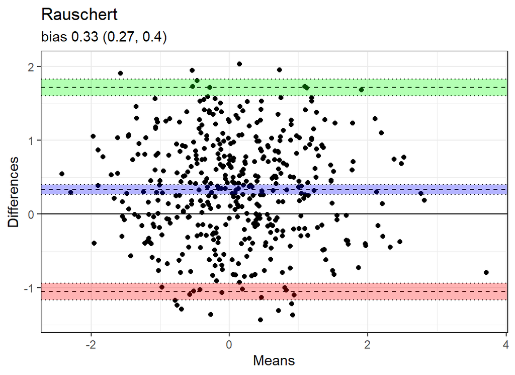

```r
blandr.plot.ggplot(BAstats_Rauschert)+
  labs(title="Rauschert", subtitle = Rauschert_biasInfo)+
  theme_bw()
```

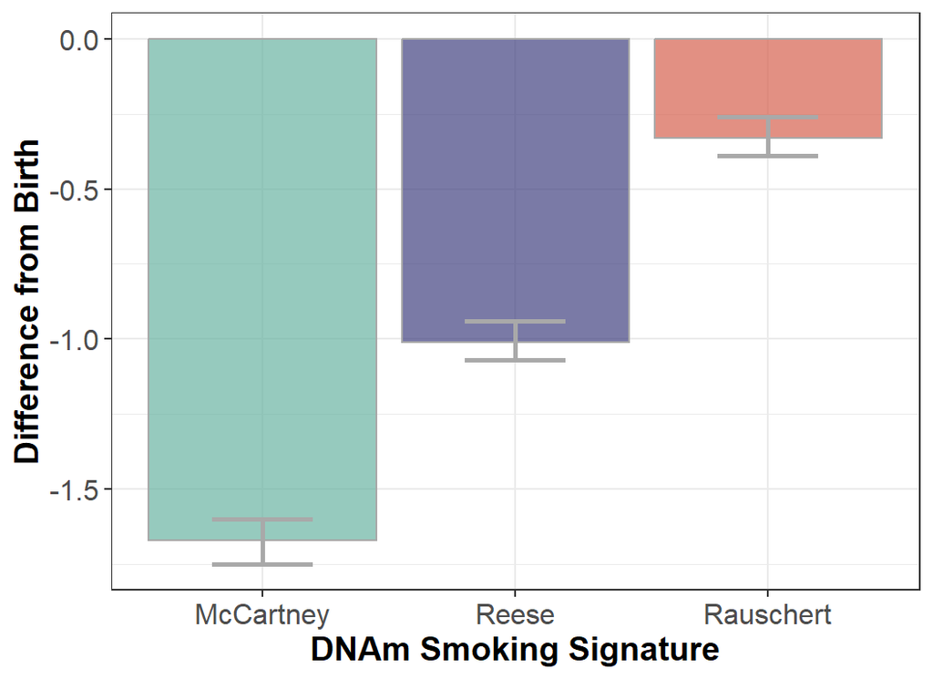

```r
###Just a quick check to see if platform makes a difference for this bias
forBA_450 = forBA[which(forBA$platform.CB=="450K" & forBA$platform.notCB=="450K"),]
forBA_EPIC = forBA[which(forBA$platform.CB=="EPIC" & forBA$platform.notCB=="EPIC"),]

BAstats_Reese_450K = blandr.statistics(forBA_450$Reese_CB, forBA_450$Reese_notCB)
BAstats_Reese_EPIC = blandr.statistics(forBA_EPIC$Reese_CB, forBA_EPIC$Reese_notCB)

BAstats_McCartney_450K = blandr.statistics(forBA_450$McCartney_CB, forBA_450$McCartney_notCB)
BAstats_McCartney_EPIC = blandr.statistics(forBA_EPIC$McCartney_CB, forBA_EPIC$McCartney_notCB)

Reese_biasInfo_450K = paste0("bias ", round(BAstats_Reese_450K$bias, 2), " (", round(BAstats_Reese_450K$biasLowerCI, 2), ", ", round(BAstats_Reese_450K$biasUpperCI, 2), ")")
McCartney_biasInfo_450K = paste0("bias ", round(BAstats_McCartney_450K$bias, 2), " (", round(BAstats_McCartney_450K$biasLowerCI, 2), ", ", round(BAstats_McCartney_450K$biasUpperCI, 2), ")")

Reese_biasInfo_EPIC = paste0("bias ", round(BAstats_Reese_EPIC$bias, 2), " (", round(BAstats_Reese_EPIC$biasLowerCI, 2), ", ", round(BAstats_Reese_EPIC$biasUpperCI, 2), ")")
McCartney_biasInfo_EPIC = paste0("bias ", round(BAstats_McCartney_EPIC$bias, 2), " (", round(BAstats_McCartney_EPIC$biasLowerCI, 2), ", ", round(BAstats_McCartney_EPIC$biasUpperCI, 2), ")")

#Reese_biasInfo_450K
#Reese_biasInfo_EPIC

#McCartney_biasInfo_450K
#McCartney_biasInfo_EPIC

## The biases look like we would expect them.

biases = read.csv(file="C:/Users/vanderll/Documents/Norris/smokingExposure_DNAmSignature/data/compare3signatureBiases.csv")
biases$study =  factor(biases$study, levels=c("McCartney", "Reese", "Rauschert"))

biases2 = biases
biases2$bias = -biases2$bias
biases2$low = -biases2$low
biases2$up = -biases2$up

ggplot(biases) +
    geom_bar( aes(x=study, y=bias), stat="identity", fill=c("#69b3a2", "#404080",  "#D6604D"), color="darkgray", alpha=0.7) +
    geom_errorbar( aes(x=study, ymin=low, ymax=up), width=0.4, colour="darkgray", alpha=1, size=1)+
  theme_bw()+
  ylab("Difference from Birth")+
  xlab("DNAm Smoking Signature")+
  theme(axis.title=element_text(size=14,face="bold"),
        plot.title = element_text(size=22,face="bold"),
        axis.text=element_text(size=12))
```

Okay, so this makes sense. Here we see that Reese is tighter and is looking like what the ICC is telling us.

Just a quick note on the number of subjects. This is 179 CB samples and of these, there are 419 other time measures that have a CB sample.

So in both measures, the scores **decrease** after CB. The differences plotted are cord blood - later measure. This corresponds to what we see in the spaghetti plots as well.

# Subject specific intercepts

We are using the DNAm smoking signature as a proxy for in-utero exposure to mom smoking. **For those with cord blood measurements as well, how does subject specific intercepts for the signature compare to the signature measured at birth?**

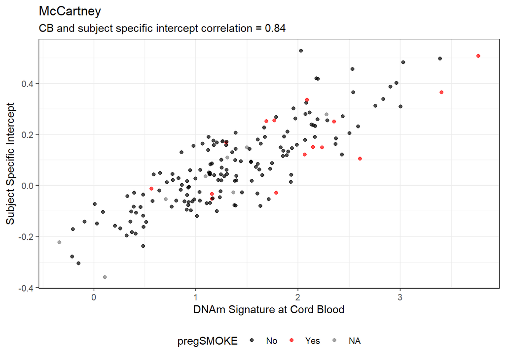

```r
#Get mixed models without scaling so you can compare to original cord blood measures
McCartney.mixMod.noScaled <- lme(DNAm.smoke.McCartney ~ clinage + platform, data = smoke.wPheno.noTR, random = ~ clinage | ID)
Reese.mixMod.noScaled <- lme(DNAm.smoke.Reese ~ clinage + platform, data = smoke.wPheno.noTR, random = ~ clinage | ID )
Rauschert.mixMod.noScaled <- lme(normalized_smokeScore ~ clinage + platform, data=smoke.wPheno2, random = ~clinage | ID)

#Extract the subject specific intercepts and slopes from each model
McCartney.random.slope = ranef(McCartney.mixMod.noScaled)[2]
McCartney.random.intercept = ranef(McCartney.mixMod.noScaled)[1]

Reese.random.slope = ranef(Reese.mixMod.noScaled)[2]
Reese.random.intercept = ranef(Reese.mixMod.noScaled)[1]

Rauschert.random.slope = ranef(Rauschert.mixMod.noScaled)[2]
Rauschert.random.intercept = ranef(Rauschert.mixMod.noScaled)[1]

#Put these random intercepts and slopes in a data frame for comparison and analyses
dat.subjSummary = data.frame(ID = rownames(Reese.random.slope), McCartney.int = McCartney.random.intercept$`(Intercept)`, McCartney.slope = McCartney.random.slope$clinage, Reese.int = Reese.random.intercept$`(Intercept)`, Reese.slope = Reese.random.slope$clinage, Rauschert.int = Rauschert.random.intercept$`(Intercept)`, Rauschert.slope = Rauschert.random.slope$clinage)

#Merge for comparison with original CB DNAm signature scores;
dat.CB.vInt = merge(CB.2, dat.subjSummary, by="ID")
dat.CB.vInt.TRs = dat.CB.vInt[which(dat.CB.vInt$ID %in% dat.CB.vInt$ID[duplicated(dat.CB.vInt$ID)]),]
dat.CB.vInt2 = dat.CB.vInt[!duplicated(dat.CB.vInt$ID),]

pheno.byID = smoke.wPheno.noTR[,c("ID", "T1Dgroup", "SEX", "IAgroup2", "cohortgrp2", "NHW" , "dr34")]
pheno.byID = pheno.byID[!duplicated(pheno.byID),]
dat.CB.vInt2 = merge(dat.CB.vInt2, pheno.byID, by="ID")

pheno.additional = readxl::read_xlsx("C:/Users/vanderll/Documents/Norris/smokingExposure_DNAmSignature/dataRaw/additional data.xlsx", sheet="data")
pheno.additional.ID = pheno.additional[!duplicated(pheno.additional$ID),]

dat.CB.vInt2 = merge(dat.CB.vInt2, pheno.additional.ID[,-c(3,4)], by="ID")



McCartney.CB.int.cor = cor.test(dat.CB.vInt$McCartney_CB, dat.CB.vInt$McCartney.int)
McCartney.cor = round(McCartney.CB.int.cor$estimate, 2)
ggplot(dat.CB.vInt2, aes(x = McCartney_CB, y = McCartney.int, color = pregSMOKE)) +
  geom_point(alpha=0.7)+
  scale_color_manual(values=c("black", "red", "gray"))+
  scale_fill_manual(values=c("black", "red", "gray")) +
  ylab("Subject Specific Intercept")+
  xlab("DNAm Signature at Cord Blood")+
  ggtitle("McCartney", subtitle = paste0("CB and subject specific intercept correlation = ", McCartney.cor))+
  theme_bw()+
  theme(legend.position = "bottom")
```

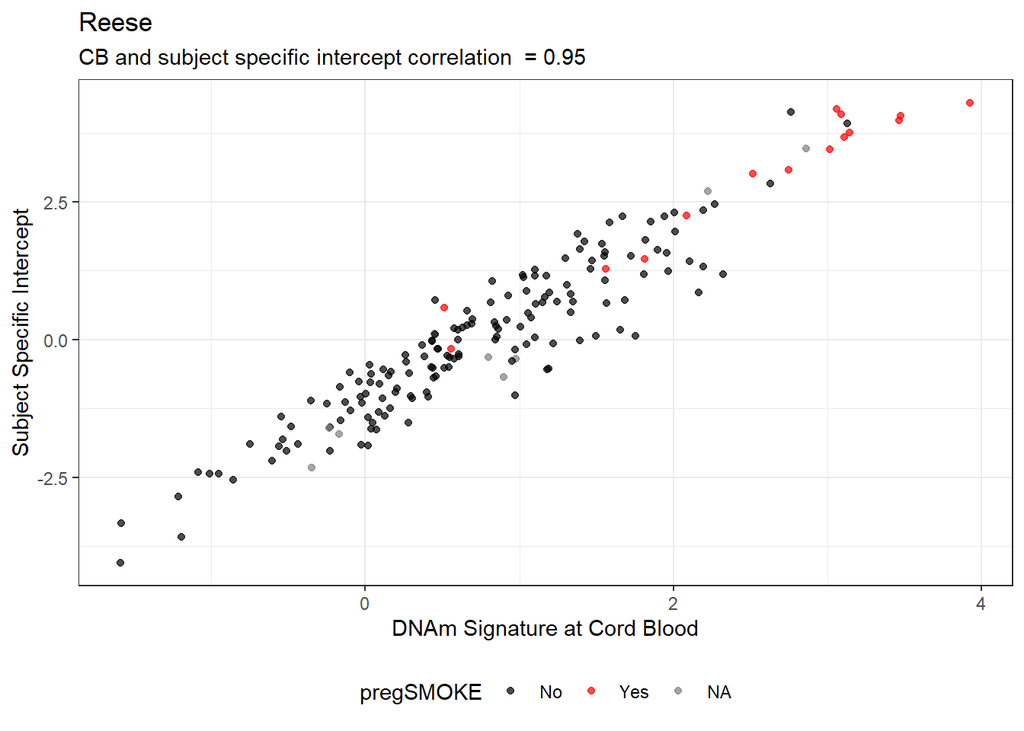

```r
Reese.CB.int.cor = cor.test(dat.CB.vInt$Reese_CB, dat.CB.vInt$Reese.int)
Reese.cor = round(Reese.CB.int.cor$estimate, 2)
ggplot(dat.CB.vInt2, aes(x = Reese_CB, y = Reese.int,color = pregSMOKE)) +
  geom_point(alpha=0.7)+
  scale_color_manual(values=c("black", "red", "gray"))+
  scale_fill_manual(values=c("black", "red", "gray")) +
  ylab("Subject Specific Intercept")+
  xlab("DNAm Signature at Cord Blood")+
  ggtitle("Reese", subtitle = paste0("CB and subject specific intercept correlation  = ", Reese.cor))+
  theme_bw()+
  theme(legend.position = "bottom")
```

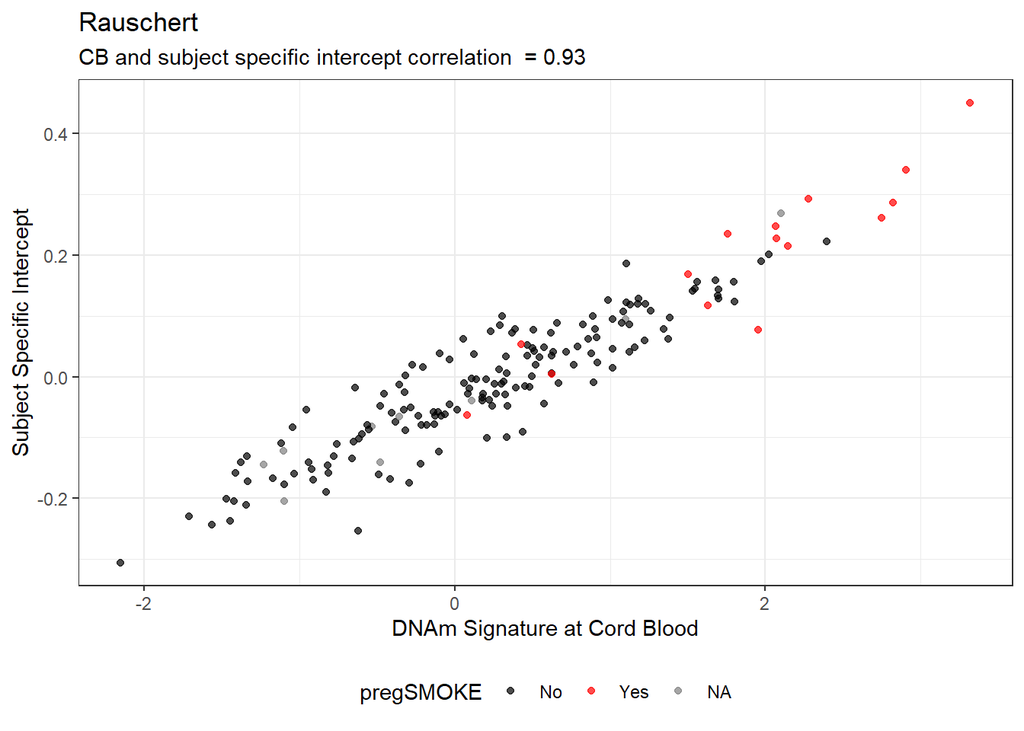

```r
Rauschert.CB.int.cor = cor.test(dat.CB.vInt$Rauschert_CB, dat.CB.vInt$Rauschert.int)
Rauschert.cor = round(Rauschert.CB.int.cor$estimate, 2)
ggplot(dat.CB.vInt2, aes(x = Rauschert_CB, y = Rauschert.int, color = pregSMOKE)) +
  geom_point(alpha=0.7)+
  scale_color_manual(values=c("black", "red", "gray"))+
  scale_fill_manual(values=c("black", "red", "gray")) +
  ylab("Subject Specific Intercept")+
  xlab("DNAm Signature at Cord Blood")+
  ggtitle("Rauschert", subtitle = paste0("CB and subject specific intercept correlation  = ", Rauschert.cor))+
  theme_bw()+
  theme(legend.position = "bottom")
```

# Association with IA

Instead of doing the cross-sectional approach like Ellen, let’s do a mixed model with all data possible.

```r
dat = both.smokes2.wP[!duplicated(both.smokes2.wP$samplekey),]
dat.ia = dat[-which(dat$IAgroup2==""),]
dat.ia$IA_binary = ifelse(dat.ia$IAgroup2=="case", 1, 0)

mod.McC <- glmer(IA_binary ~ scale(DNAm.smoke.McCartney) + cohortgrp2 + dr34 + clinage + (1 | ID), data = dat.ia , family = binomial(link="logit"))
mod.Reese <- glmer(IA_binary ~ scale(DNAm.smoke.Reese) + cohortgrp2 + dr34 + clinage + (1 | ID), data = dat.ia , family = binomial(link="logit"))
mod.Rauschert <- glmer(IA_binary ~ normalized_smokeScore + cohortgrp2 + dr34 + clinage +  (1 | ID), data = dat.ia , family = binomial(link="logit"))

mod.McC <- lme(DNAm.smoke.McCartney~IA_binary + cohortgrp2 + dr34 + clinage, random=~1|ID, dat=dat.ia)
mod.Reese <- lme(DNAm.smoke.Reese~IA_binary + cohortgrp2 + dr34 + clinage, random=~1|ID, dat=dat.ia)
mod.Rauschert <- lme(normalized_smokeScore~IA_binary + cohortgrp2 + dr34 + clinage, random=~1|ID, dat=dat.ia)

mod.Rauschert.GP <- lme(normalized_smokeScore~IA_binary + dr34 + clinage, random=~1|ID, dat=dat.ia[which(dat.ia$cohortgrp2=="GP"),])
mod.Rauschert.FDR <- lme(normalized_smokeScore~IA_binary + dr34 + clinage, random=~1|ID, dat=dat.ia[which(dat.ia$cohortgrp2=="FDR"),])


mod.Reese.GP <- lme(scale(DNAm.smoke.Reese)~IA_binary + dr34 + clinage, random=~1|ID, dat=dat.ia[which(dat.ia$cohortgrp2=="GP"),])
mod.Reese.FDR <- lme(scale(DNAm.smoke.Reese)~IA_binary + dr34 + clinage, random=~1|ID, dat=dat.ia[which(dat.ia$cohortgrp2=="FDR"),])

mod.McC.GP <- lme(DNAm.smoke.McCartney~IA_binary + dr34 + clinage, random=~1|ID, dat=dat.ia[which(dat.ia$cohortgrp2=="GP"),])
mod.McC.FDR <- lme(DNAm.smoke.McCartney~IA_binary + dr34 + clinage, random=~1|ID, dat=dat.ia[which(dat.ia$cohortgrp2=="FDR"),])

summary(mod.McC.GP)
```

```
## Linear mixed-effects model fit by REML
##   Data: dat.ia[which(dat.ia$cohortgrp2 == "GP"), ]
##        AIC      BIC    logLik
##   352.9802 378.6626 -170.4901
##
## Random effects:
##  Formula: ~1 | ID
##         (Intercept)  Residual
## StdDev:    0.208726 0.2788441
##
## Fixed effects:  DNAm.smoke.McCartney ~ IA_binary + dr34 + clinage
##                  Value  Std.Error  DF   t-value p-value
## (Intercept)  1.4485334 0.03310893 374  43.75054  0.0000
## IA_binary   -0.0631967 0.04167030 160  -1.51659  0.1313
## dr34        -0.0214803 0.04259568 160  -0.50428  0.6148
## clinage     -0.0716284 0.00283610 374 -25.25597  0.0000
##  Correlation:
##           (Intr) IA_bnr dr34
## IA_binary -0.516
## dr34      -0.400 -0.163
## clinage   -0.320  0.009 -0.030
##
## Standardized Within-Group Residuals:
##         Min          Q1         Med          Q3         Max
## -2.30453940 -0.64055234 -0.03743167  0.56288635  2.85659268
##
## Number of Observations: 538
## Number of Groups: 163
```